# R Notebook

### This code is running using R notebook in RStudio

### 1.0 Goul:

Our main goal in collecting the Arab Employee dataset is to learn more about what affects how much Arab professionals get paid. We want to gather information about their qualifications, where they live, and how much experience they have. This data will help organizations and policymakers make better decisions about managing talent, planning for the future workforce, and making sure pay is fair in the Arab region.

#### 1.1 Classification Goal:

We want to group employees into different categories based on their qualifications, country location, and experience. By doing this, we can see patterns and trends among different groups. This will help us understand if there are differences in pay based on qualifications and experience, and it will help us identify talented individuals. With this information, we can develop strategies to support career growth and make sure people are being paid fairly.

#### 1.2 Clustering Goal:

We want to group similar data points so we grouped employees with similar salaries together. By doing this, will help in uncovering hidden patterns and structures within the data, making it easier to understand the inherent relationships between different employees’ info. It also makes it feasible to divide our enormous dataset into smaller, easier-to-understand subsets. This can make analyzing complicated datasets easier.

#### 1.3 Defect Prediction Goal:

We want to use machine learning and statistical techniques to create models that can predict any issues or anomalies with employee salaries. This could include things like unfair pay practices, wage gaps, or differences based on qualifications or experience. By catching these problems early, we can fix them and make sure everyone is being treated fairly. This analysis will help us improve compensation policies and make better decisions about managing talent.

#### 1.4 By achieving these goals, we can:

Understand how salaries are distributed among different employee groups. Identify any biases or unfairness in pay based on qualifications, experience, or location. Develop strategies for hiring, developing, and keeping talented employees. Make sure pay practices are fair and transparent. Catch and fix salary-related issues before they become bigger problems. Plan for the future workforce and allocate resources effectively. Make better decisions about pay and talent management in the Arab region. Overall, collecting the Arab Employee dataset with information about salary, qualifications, location, and experience is really important. It will help us analyze the data and make fair decisions that create a good working environment for Arab professionals.

### 2.1 Source of the dataset:

Kaggle

### 2.2 link of the dataset:

https://www.kaggle.com/datasets/qusaybtoush1990/employes

### 3.0 General Information about Employees dataset:

Our dataset contains 10 attributes (See Table 1), and 740 objects. Furthermore, class lables the class label for our dataset is Salary.

### 3.1 Table 1: General Information about the attributes for Employees dataset.

[output not shown]

#### 3.2 Sample of Employees dataset

```r
View(Employees)
```

#### 3.3 Number of column and rows

```r
dim(Employees)
```

```
[1] 740  10
```

#### 3.4 statiscal summarise -Nominal-

```r
summary(Employees$Education)
```

```
   Length     Class      Mode
      740 character character
```

```r
summary(Employees$Department)
```

```
   Length     Class      Mode
      740 character character
```

```r
summary(Employees$'Job Status')
```

```
   Length     Class      Mode
      740 character character
```

```r
summary(Employees$Location)
```

```
   Length     Class      Mode
      740 character character
```

#### 3.5 statiscal summarise -Numerical-

```r
summary(Employees$Years)
```

```
   Min. 1st Qu.  Median    Mean 3rd Qu.    Max.
  0.000   2.000   4.000   3.924   6.000   9.000
```

```r
summary(Employees$Salary)
```

```
   Min. 1st Qu.  Median    Mean 3rd Qu.    Max.
  650.0   970.8  1580.5  1517.6  2074.0  2500.0
```

```r
summary(Employees$'Job Rate')
```

```
   Min. 1st Qu.  Median    Mean 3rd Qu.    Max.
  1.000   3.000   5.000   5.292   8.000  13.000
```

```r
summary(Employees$Permissions)
```

```
   Min. 1st Qu.  Median    Mean 3rd Qu.    Max.
  1.000   4.000   7.000   7.435  11.000  14.000
```

Description of summary: This is the summary of all data set

#### 3.6 Code for variance

```r
var(Employees$Salary)
```

```
[1] 353862
```

### 4.0 Graphs

#### 4.1 Box plot for salary and years

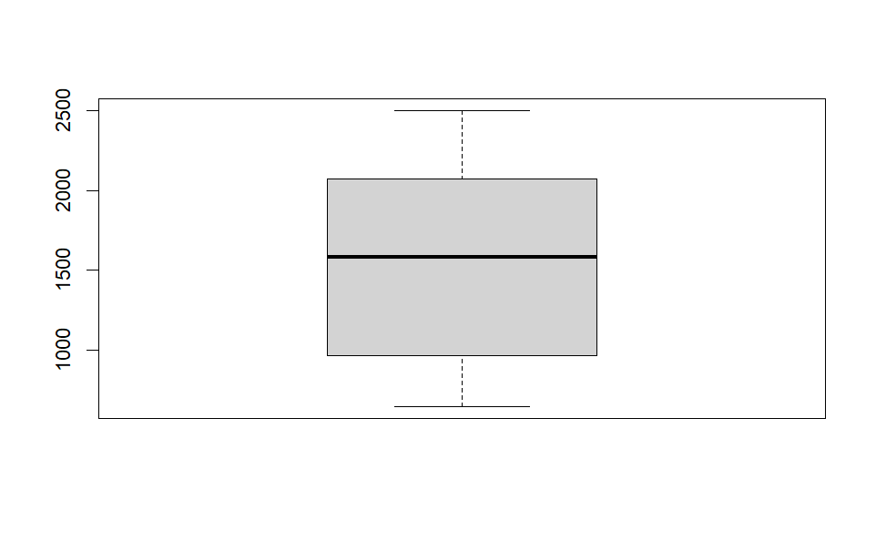

```r
boxplot(Employees$Salary)
```

Description for Salary boxplot: The Salary boxplot illustrates that the salaries are evenly distributed around the middle point, indicating a relatively balanced salary distribution.

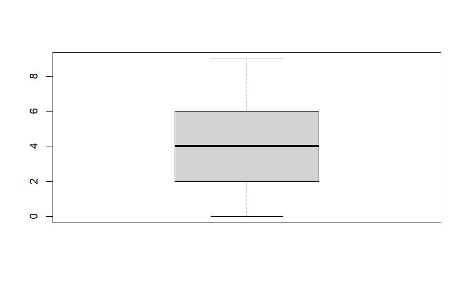

```r
boxplot(Employees$Years)
```

Description for Years boxplot: The Years of Work boxplot illustrates how the values in the dataset have relatively balanced around the median value of 4.

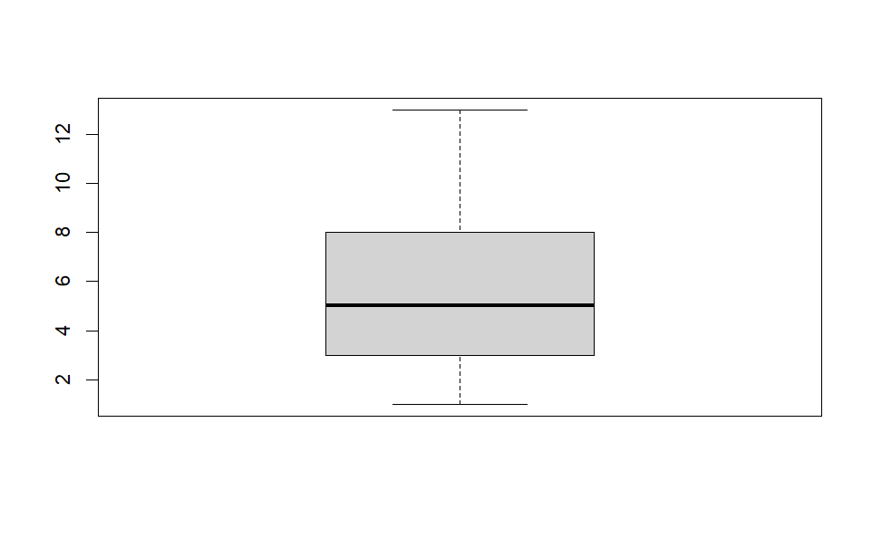

```r
boxplot(Employees$'Job Rate')
```

Description for Job rate boxplot: The Job rate boxplot is relatively balanced around the median value of 5. In a more comprehensive analysis, there is a spread in the job rates above 50% of the dataset.

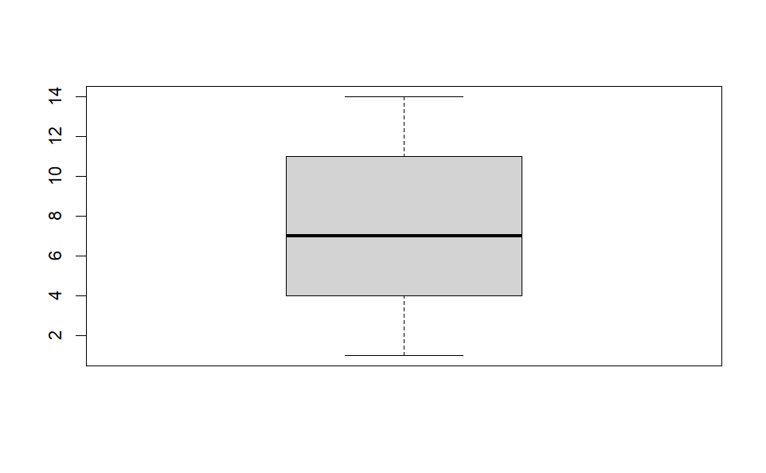

```r
boxplot(Employees$Permissions)
```

Description for Permissions boxplot: The Permissions boxplot reveals several important insights about the distribution of Permissions. It illustrates that the values of the attribute are almost balanced near to the median.

#### 4.2 Histogram for permission

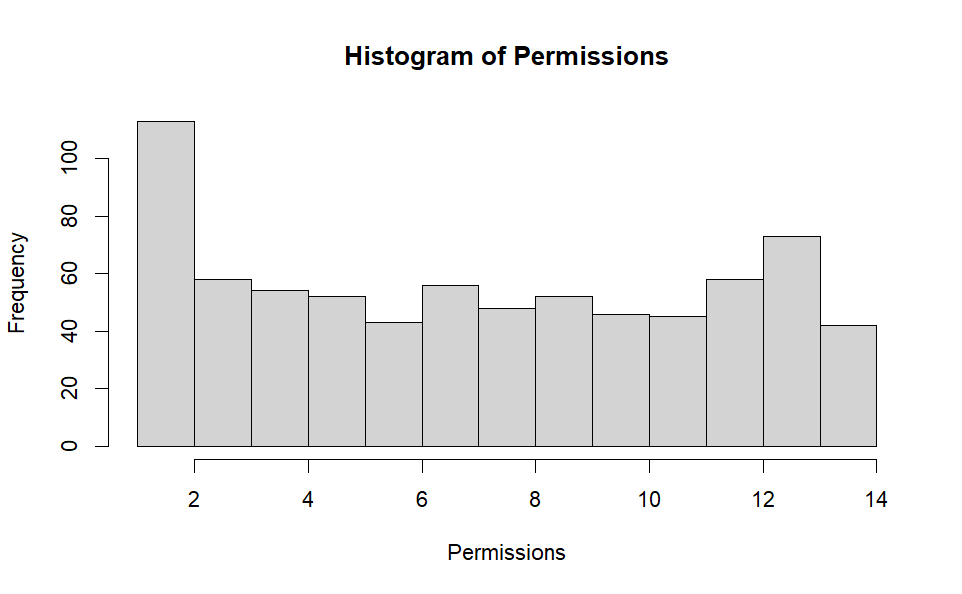

```r
Permissions <- Employees$Permissions
hist(Permissions)
```

Description for Permissions histogram.: The frequency of Permissions for the employees in the dataset is represented by the histogram. After observation, we noticed that the most values lie in approximately from 1 permission to 2. As for the rest of the employees, their Permissions range from 3 to 14 permission.

#### 4.3 Bar Chart for Salary

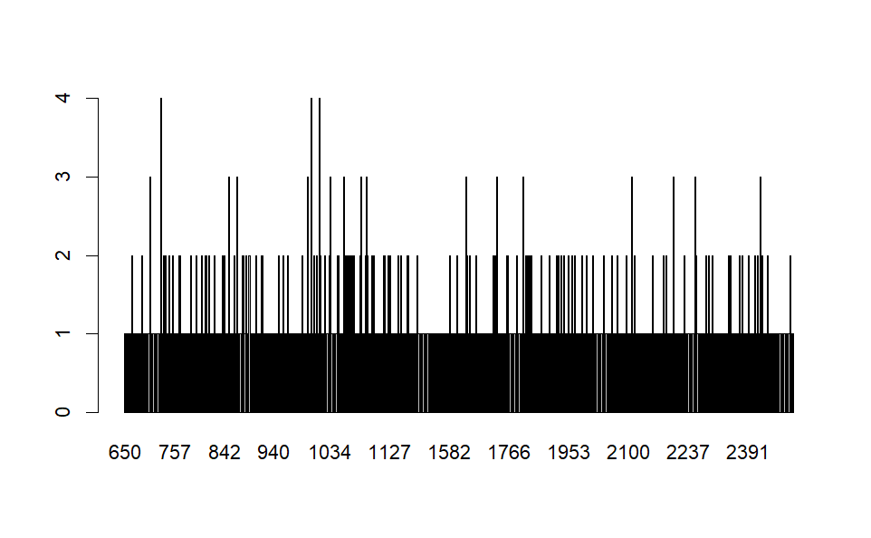

```r
#Bar Chart

Employees$Salary %>% table() %>% barplot()
```

Description for Bar Chart for Salary: The frequency of Salary for the employees in the dataset is represented by the Bar chart. Since the bar chart is made for salary, the frequency of each value mostly appears ones. For best representation; it will be better to do discretisation before.

#### 4.4 pie chart for Education

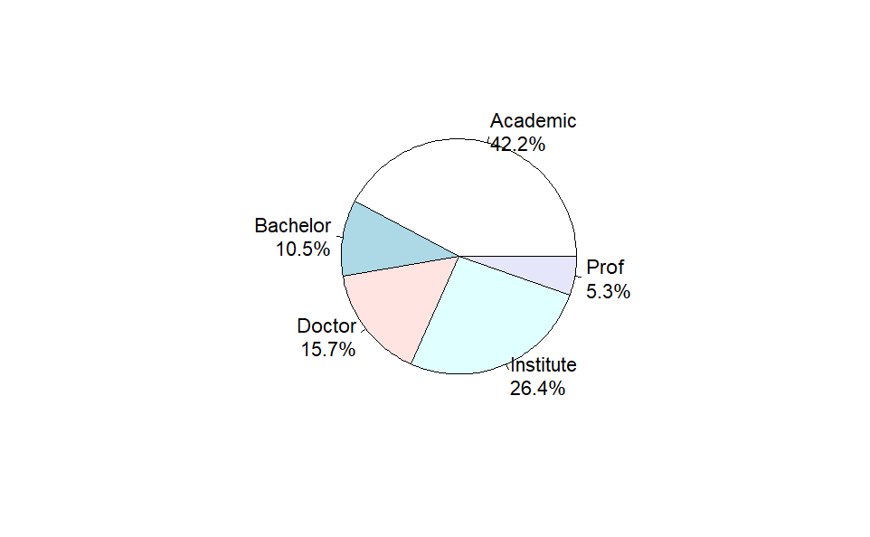

```r
tab <- Employees$Education %>% table()
precentages <- tab %>% prop.table() %>% round(3) * 100
txt <- paste0(names(tab), '\n', precentages, '%')
pie(tab, labels=txt)
```

Description for Education pie chart: The pie chart shows that approximately half of the employees have academic education, and a few employees are prof, which helps us predict their salaries according to their level of education.

### 5.0.0 Data preprocessing

### 5.1.0 Data cleaning

#### 5.1.1 To find the total null values in the dataset

```r
dim(Employees)
```

```
[1] 740  10
```

```r
sum(is.na(Employees))
```

```
[1] 0
```

#### 5.1.2 Replace missing Data with average value

```r
Employees$Years = ifelse(is.na(Employees$Years), ave(Employees$Years, FUN =function(x) mean(x,na.rm=TRUE)), Employees$Years)
View(Employees)
```

Description of data cleaning: We checked if our data contains missing or null values and replace these missing values with average value to get more efficient dataset.

#### 5.1.3 Detecting outliers

```r
OutSalary = outlier(Employees$Salary, logical =TRUE)
sum(OutSalary)
```

```
[1] 1
```

```r
Find_outlierSalary = which(OutSalary ==TRUE, arr.ind = TRUE)
OutSalary
```

```
  [1] FALSE FALSE FALSE FALSE FALSE FALSE FALSE FALSE FALSE FALSE FALSE FALSE FALSE FALSE FALSE FALSE FALSE
 [18] FALSE FALSE FALSE FALSE FALSE FALSE FALSE FALSE FALSE FALSE FALSE FALSE FALSE FALSE FALSE FALSE FALSE
 [35] FALSE FALSE FALSE FALSE FALSE FALSE FALSE FALSE FALSE FALSE FALSE FALSE FALSE FALSE FALSE FALSE FALSE
 [52] FALSE FALSE FALSE FALSE FALSE FALSE FALSE FALSE FALSE FALSE FALSE FALSE FALSE FALSE FALSE FALSE FALSE
 [69] FALSE FALSE FALSE FALSE FALSE FALSE FALSE FALSE FALSE FALSE FALSE FALSE FALSE FALSE FALSE FALSE FALSE
 [86] FALSE FALSE FALSE FALSE FALSE FALSE FALSE FALSE FALSE FALSE FALSE FALSE FALSE FALSE FALSE FALSE FALSE
[103] FALSE FALSE FALSE FALSE FALSE FALSE FALSE FALSE FALSE FALSE FALSE FALSE FALSE FALSE FALSE FALSE FALSE
[120] FALSE FALSE FALSE FALSE FALSE FALSE FALSE FALSE FALSE FALSE FALSE FALSE FALSE FALSE FALSE FALSE FALSE
[137]  TRUE FALSE FALSE FALSE FALSE FALSE FALSE FALSE FALSE FALSE FALSE FALSE FALSE FALSE FALSE FALSE FALSE
[154] FALSE FALSE FALSE FALSE FALSE FALSE FALSE FALSE FALSE FALSE FALSE FALSE FALSE FALSE FALSE FALSE FALSE
[171] FALSE FALSE FALSE FALSE FALSE FALSE FALSE FALSE FALSE FALSE FALSE FALSE FALSE FALSE FALSE FALSE FALSE
[188] FALSE FALSE FALSE FALSE FALSE FALSE FALSE FALSE FALSE FALSE FALSE FALSE FALSE FALSE FALSE FALSE FALSE
[205] FALSE FALSE FALSE FALSE FALSE FALSE FALSE FALSE FALSE FALSE FALSE FALSE FALSE FALSE FALSE FALSE FALSE
[222] FALSE FALSE FALSE FALSE FALSE FALSE FALSE FALSE FALSE FALSE FALSE FALSE FALSE FALSE FALSE FALSE FALSE
[239] FALSE FALSE FALSE FALSE FALSE FALSE FALSE FALSE FALSE FALSE FALSE FALSE FALSE FALSE FALSE FALSE FALSE
```

[output cut: 29 more lines]

```r
Find_outlierSalary
```

```
[1] 137
```

```r
OutPermissions = outlier(Employees$Permissions, logical =TRUE)
sum(OutPermissions)
```

```
[1] 42
```

```r
Find_outlierPre = which(OutPermissions ==TRUE, arr.ind = TRUE)
OutPermissions
```

```
  [1] FALSE FALSE FALSE FALSE FALSE FALSE FALSE FALSE FALSE FALSE FALSE FALSE FALSE FALSE FALSE FALSE FALSE
 [18] FALSE FALSE FALSE  TRUE FALSE FALSE FALSE FALSE FALSE FALSE FALSE FALSE FALSE FALSE FALSE FALSE  TRUE
 [35] FALSE FALSE FALSE FALSE FALSE FALSE FALSE FALSE FALSE FALSE FALSE FALSE FALSE FALSE FALSE FALSE FALSE
 [52] FALSE FALSE FALSE FALSE FALSE FALSE FALSE FALSE FALSE  TRUE FALSE FALSE FALSE FALSE FALSE FALSE FALSE
 [69] FALSE FALSE FALSE FALSE FALSE FALSE FALSE FALSE FALSE FALSE FALSE FALSE FALSE FALSE FALSE FALSE FALSE
 [86] FALSE FALSE FALSE FALSE FALSE FALSE FALSE FALSE FALSE FALSE  TRUE FALSE FALSE FALSE FALSE FALSE FALSE
[103] FALSE FALSE FALSE FALSE FALSE FALSE FALSE FALSE FALSE FALSE FALSE FALSE FALSE FALSE FALSE  TRUE FALSE
[120] FALSE FALSE FALSE FALSE FALSE FALSE FALSE FALSE  TRUE FALSE FALSE FALSE FALSE FALSE FALSE FALSE FALSE
[137] FALSE FALSE FALSE FALSE FALSE  TRUE FALSE FALSE FALSE FALSE FALSE FALSE FALSE FALSE FALSE FALSE FALSE
[154] FALSE FALSE FALSE FALSE FALSE FALSE FALSE FALSE FALSE FALSE FALSE FALSE FALSE FALSE FALSE FALSE FALSE
[171] FALSE FALSE FALSE FALSE FALSE FALSE FALSE FALSE FALSE  TRUE FALSE FALSE FALSE FALSE FALSE FALSE FALSE
[188] FALSE FALSE FALSE FALSE FALSE FALSE FALSE FALSE FALSE FALSE FALSE FALSE FALSE FALSE FALSE  TRUE FALSE
[205] FALSE FALSE FALSE FALSE FALSE FALSE FALSE FALSE  TRUE FALSE FALSE FALSE FALSE FALSE  TRUE FALSE FALSE
[222] FALSE FALSE FALSE FALSE FALSE  TRUE FALSE FALSE FALSE FALSE  TRUE FALSE FALSE FALSE FALSE FALSE FALSE
[239] FALSE FALSE FALSE FALSE FALSE FALSE FALSE FALSE FALSE FALSE FALSE FALSE FALSE  TRUE FALSE  TRUE FALSE
```

[output cut: 29 more lines]

```r
Find_outlierPre
```

```
 [1]  21  34  61  96 118 128 142 180 203 213 219 227 232 252 254 278 279 283 286 291 298 319 353 355 361 364
[27] 387 412 463 494 513 580 587 589 613 614 637 659 666 680 729 734
```

```r
OutJobRate= outlier(Employees$'Job Rate', logical =TRUE)
sum(OutJobRate)
```

```
[1] 21
```

```r
Find_outlierJob = which(OutJobRate ==TRUE, arr.ind = TRUE)
OutJobRate
```

```
  [1] FALSE FALSE FALSE FALSE FALSE FALSE  TRUE FALSE FALSE FALSE FALSE FALSE FALSE FALSE FALSE FALSE FALSE
 [18] FALSE FALSE FALSE FALSE FALSE  TRUE FALSE FALSE FALSE FALSE FALSE FALSE FALSE FALSE  TRUE FALSE FALSE
 [35] FALSE FALSE FALSE FALSE FALSE FALSE FALSE FALSE FALSE FALSE FALSE FALSE FALSE FALSE FALSE FALSE FALSE
 [52] FALSE FALSE FALSE FALSE FALSE FALSE FALSE FALSE FALSE FALSE FALSE FALSE FALSE FALSE FALSE FALSE FALSE
 [69] FALSE FALSE FALSE FALSE FALSE FALSE  TRUE FALSE FALSE FALSE FALSE FALSE FALSE FALSE FALSE FALSE FALSE
 [86] FALSE FALSE FALSE FALSE FALSE FALSE FALSE FALSE FALSE FALSE FALSE FALSE FALSE FALSE FALSE FALSE FALSE
[103] FALSE FALSE FALSE FALSE FALSE FALSE FALSE  TRUE FALSE FALSE FALSE FALSE FALSE FALSE FALSE FALSE FALSE
[120] FALSE FALSE FALSE FALSE FALSE FALSE FALSE FALSE FALSE FALSE FALSE FALSE FALSE FALSE FALSE FALSE FALSE
[137] FALSE FALSE FALSE FALSE  TRUE FALSE FALSE FALSE FALSE FALSE FALSE FALSE FALSE FALSE FALSE FALSE FALSE
[154] FALSE FALSE FALSE FALSE FALSE FALSE FALSE FALSE FALSE FALSE FALSE FALSE FALSE FALSE FALSE FALSE FALSE
[171] FALSE FALSE FALSE FALSE FALSE FALSE FALSE FALSE FALSE FALSE FALSE FALSE FALSE FALSE FALSE FALSE FALSE
[188] FALSE FALSE FALSE FALSE FALSE FALSE FALSE FALSE FALSE FALSE FALSE FALSE FALSE FALSE  TRUE FALSE FALSE
[205] FALSE FALSE FALSE FALSE FALSE FALSE FALSE FALSE FALSE FALSE FALSE FALSE FALSE FALSE FALSE FALSE FALSE
[222] FALSE FALSE FALSE FALSE FALSE FALSE FALSE FALSE FALSE FALSE FALSE FALSE FALSE FALSE FALSE FALSE FALSE
[239] FALSE FALSE FALSE FALSE FALSE FALSE FALSE FALSE FALSE FALSE FALSE FALSE FALSE FALSE FALSE FALSE FALSE
```

[output cut: 29 more lines]

```r
Find_outlierJob
```

```
 [1]   7  23  32  75 110 141 202 256 278 300 336 454 476 485 513 543 565 600 679 683 725
```

```r
OutYears= outlier(Employees$Years, logical =TRUE)
sum(OutYears)
```

```
[1] 5
```

```r
Find_outlierYears = which(OutYears ==TRUE, arr.ind = TRUE)
OutYears
```

```
  [1] FALSE FALSE FALSE FALSE FALSE FALSE FALSE FALSE FALSE FALSE FALSE FALSE FALSE FALSE FALSE FALSE FALSE
 [18] FALSE FALSE FALSE FALSE FALSE FALSE FALSE FALSE FALSE FALSE FALSE FALSE FALSE FALSE FALSE FALSE FALSE
 [35] FALSE FALSE FALSE FALSE FALSE FALSE FALSE FALSE FALSE FALSE FALSE FALSE FALSE FALSE FALSE FALSE FALSE
 [52] FALSE FALSE FALSE FALSE FALSE FALSE FALSE FALSE FALSE FALSE FALSE FALSE FALSE FALSE FALSE FALSE FALSE
 [69] FALSE FALSE FALSE FALSE FALSE FALSE FALSE FALSE FALSE FALSE FALSE FALSE FALSE FALSE FALSE FALSE FALSE
 [86] FALSE FALSE FALSE FALSE FALSE FALSE FALSE FALSE FALSE FALSE FALSE FALSE FALSE FALSE FALSE FALSE FALSE
[103] FALSE FALSE FALSE FALSE FALSE  TRUE  TRUE FALSE FALSE FALSE FALSE FALSE FALSE FALSE FALSE FALSE FALSE
[120] FALSE FALSE FALSE FALSE FALSE FALSE FALSE FALSE FALSE FALSE FALSE FALSE FALSE FALSE FALSE FALSE FALSE
[137] FALSE FALSE FALSE FALSE FALSE FALSE FALSE FALSE FALSE FALSE FALSE FALSE FALSE FALSE FALSE FALSE FALSE
[154] FALSE FALSE FALSE FALSE FALSE FALSE FALSE FALSE FALSE FALSE FALSE FALSE FALSE FALSE FALSE FALSE FALSE
[171] FALSE FALSE FALSE FALSE FALSE FALSE FALSE FALSE FALSE FALSE FALSE FALSE FALSE FALSE FALSE FALSE FALSE
[188] FALSE FALSE FALSE FALSE FALSE FALSE FALSE FALSE FALSE FALSE FALSE FALSE FALSE FALSE FALSE FALSE FALSE
[205] FALSE FALSE FALSE FALSE FALSE FALSE FALSE FALSE FALSE FALSE FALSE FALSE FALSE FALSE FALSE FALSE FALSE
[222] FALSE FALSE FALSE FALSE FALSE FALSE FALSE FALSE FALSE FALSE FALSE FALSE FALSE FALSE FALSE FALSE FALSE
[239] FALSE FALSE FALSE FALSE FALSE FALSE FALSE FALSE FALSE FALSE FALSE FALSE FALSE FALSE FALSE FALSE FALSE
```

[output cut: 29 more lines]

```r
Find_outlierYears
```

```
[1] 108 109 382 468 490
```

```r
summary(Employees)
```

```
      ID             Education          Department         Job Status          Location
 Length:740         Length:740         Length:740         Length:740         Length:740
 Class :character   Class :character   Class :character   Class :character   Class :character
 Mode  :character   Mode  :character   Mode  :character   Mode  :character   Mode  :character



   Start Date                         Years           Salary          Job Rate       Permissions
 Min.   :2011-01-07 00:00:00.00   Min.   :0.000   Min.   : 650.0   Min.   : 1.000   Min.   : 1.000
 1st Qu.:2013-07-15 12:00:00.00   1st Qu.:2.000   1st Qu.: 970.8   1st Qu.: 3.000   1st Qu.: 4.000
 Median :2015-09-02 12:00:00.00   Median :4.000   Median :1580.5   Median : 5.000   Median : 7.000
 Mean   :2015-08-25 23:13:17.83   Mean   :3.924   Mean   :1517.6   Mean   : 5.292   Mean   : 7.435
 3rd Qu.:2017-09-09 00:00:00.00   3rd Qu.:6.000   3rd Qu.:2074.0   3rd Qu.: 8.000   3rd Qu.:11.000
 Max.   :2020-01-01 00:00:00.00   Max.   :9.000   Max.   :2500.0   Max.   :13.000   Max.   :14.000
```

```r
str(Employees)
```

```
tibble [740 × 10] (S3: tbl_df/tbl/data.frame)
 $ ID         : chr [1:740] "8A78C6" "1N28R7" "9S94G5" "9N59A9" ...
 $ Education  : chr [1:740] "Institute" "Bachelor" "Prof" "Doctor" ...
 $ Department : chr [1:740] "FSL" "FSL" "NFI" "FSL" ...
 $ Job Status : chr [1:740] "Full Time" "Full Time" "Full Time" "Full Time" ...
 $ Location   : chr [1:740] "United Arab Emirates" "Saudi Arabia" "United Arab Emirates" "Syria" ...
 $ Start Date : POSIXct[1:740], format: "2016-08-29" "2019-02-01" "2015-07-15" ...
 $ Years      : num [1:740] 3 1 4 4 3 1 7 4 0 3 ...
 $ Salary     : num [1:740] 2371 1711 1899 2139 2181 ...
 $ Job Rate   : num [1:740] 7 9 8 7 7 1 13 9 3 4 ...
 $ Permissions: num [1:740] 3 2 4 8 11 1 5 12 1 6 ...
```

#### 5.1.4 Removing outliers

```r
Employees= Employees[-Find_outlierSalary,]
Employees= Employees[-Find_outlierPre,]
Employees= Employees[-Find_outlierJob,]
Employees= Employees[-Find_outlierYears,]
```

Description of detecting outliers, Removing outliers: This function is used to find outliers-if found- in order to remove them to have better prediction.

```r
summary(Employees)
```

```
      ID             Education          Department         Job Status          Location
 Length:672         Length:672         Length:672         Length:672         Length:672
 Class :character   Class :character   Class :character   Class :character   Class :character
 Mode  :character   Mode  :character   Mode  :character   Mode  :character   Mode  :character



   Start Date                         Years           Salary          Job Rate       Permissions
 Min.   :2011-01-07 00:00:00.00   Min.   :0.000   Min.   : 650.0   Min.   : 1.000   Min.   : 1.00
 1st Qu.:2013-07-11 12:00:00.00   1st Qu.:2.000   1st Qu.: 970.8   1st Qu.: 3.000   1st Qu.: 4.00
 Median :2015-08-23 12:00:00.00   Median :4.000   Median :1571.0   Median : 5.000   Median : 7.00
 Mean   :2015-08-18 18:27:51.43   Mean   :3.943   Mean   :1512.0   Mean   : 5.272   Mean   : 7.39
 3rd Qu.:2017-09-01 00:00:00.00   3rd Qu.:6.000   3rd Qu.:2065.8   3rd Qu.: 8.000   3rd Qu.:11.00
 Max.   :2020-01-01 00:00:00.00   Max.   :9.000   Max.   :2499.0   Max.   :13.000   Max.   :14.00
```

```r
str(Employees)
```

```
tibble [672 × 10] (S3: tbl_df/tbl/data.frame)
 $ ID         : chr [1:672] "8A78C6" "1N28R7" "9S94G5" "9N59A9" ...
 $ Education  : chr [1:672] "Institute" "Bachelor" "Prof" "Doctor" ...
 $ Department : chr [1:672] "FSL" "FSL" "NFI" "FSL" ...
 $ Job Status : chr [1:672] "Full Time" "Full Time" "Full Time" "Full Time" ...
 $ Location   : chr [1:672] "United Arab Emirates" "Saudi Arabia" "United Arab Emirates" "Syria" ...
 $ Start Date : POSIXct[1:672], format: "2016-08-29" "2019-02-01" "2015-07-15" ...
 $ Years      : num [1:672] 3 1 4 4 3 1 4 0 3 4 ...
 $ Salary     : num [1:672] 2371 1711 1899 2139 2181 ...
 $ Job Rate   : num [1:672] 7 9 8 7 7 1 9 3 4 5 ...
 $ Permissions: num [1:672] 3 2 4 8 11 1 12 1 6 10 ...
```

### 5.2.0 Discretization

```r
Employees$Salary <- cut(Employees$Salary,
                        breaks = c( 600 , 1000 , 1600 , 2600 ),
                        labels = c( "600-1000", "1000-1600", "1600-2600"))
```

Description of the discretization: This function arranges the values in intervals and give every interval a suitable label. by discretization, the Salary will be simpler to classify or perform other methods.

### 5.3.0 Encoding

```r
Employees$Education =  as.numeric(factor(Employees$Education))
```

```r
Employees$Department =  as.numeric(factor(Employees$Department))
```

```r
Employees$'Job Status' = as.numeric(factor(Employees$'Job Status'))
```

```r
Employees$Location = as.numeric(factor(Employees$Location))
```

Description of encoding: Encoding is the process of converting categorical data to numerical format. We need to convert the data to be able to do clustering.

### 5.4.0 Feature Selection

```r
set.seed(123)
Employees$Salary <- as.factor(Employees$Salary )
predictors <- Employees[, -8]
class_label <- Employees$Salary
model <- randomForest(predictors, class_label, importance = TRUE)
importance <- importance(model)
ranked_features <- sort(importance[, "MeanDecreaseGini"], decreasing = TRUE)

# Print the ranked features
print(ranked_features)
```

```
 Job Status    Job Rate          ID  Start Date Permissions  Department       Years    Location   Education
  225.77996    54.71108    33.14282    31.83270    21.48959    20.84007    13.49328    10.84080    10.78005
```

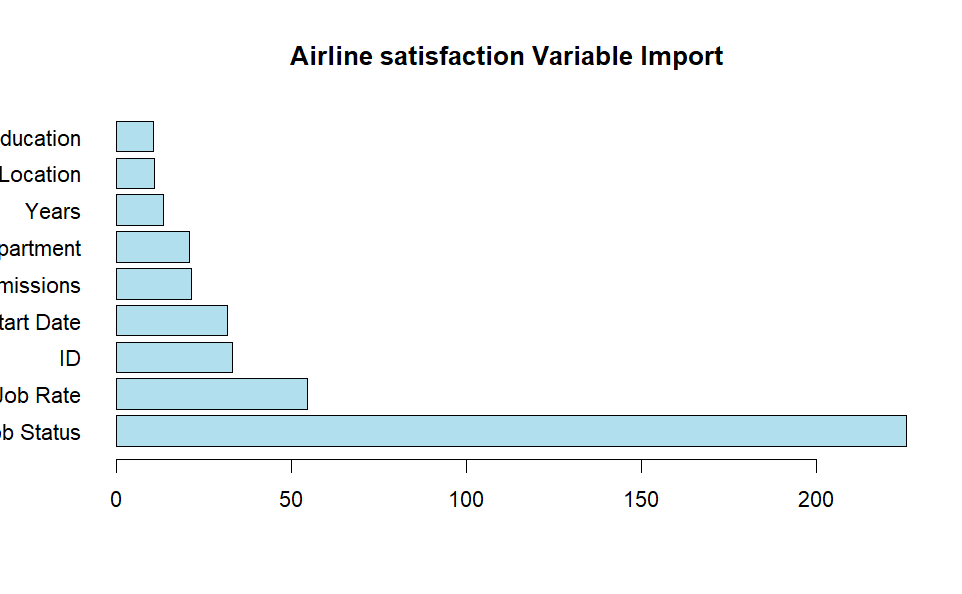

```r
barplot(ranked_features, horiz = TRUE, col = c("lightblue2"), las = 1, main = "Airline satisfaction Variable Import")
```

Description of feature selection: Feature selection is a process in machine learning, it is used to improve model performance. In several datasets, there are many features, and not all of the features participate equally to the performance of the model. Some of the features could even make redundancy or some noise. Feature selection assist in showing the most relevant features, leading to simpler and more interpretable models. In our dataset the most relevant features were “Job Status”, “Job Rate” and “ID”.

### 5.5.0 Imbalance

Description of Imbalance: Imbalance refers to a situation where the distribution of attributes in a dataset is not uniform. without imbalance tasks such as classification can be effected.

#### 5.5.1 Bar Chart for Salary

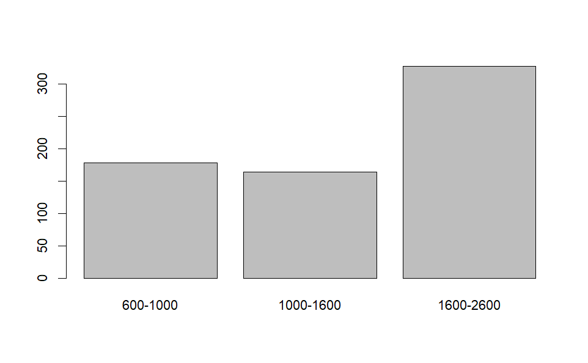

```r
#Bar Chart
Employees$Salary %>% table() %>% barplot()
```

Description of bar chart after discretization: After doing discretisation and observation, we noticed that the most values lie in approximately from 1600 to 2600. while from 600-1000 and 1000-1600 are close to each other. The range of Salaries has big difference, which we have to consider it for the classification and clustering.

#### 5.5.2 Convert Salary column to factor

```r
Employees$Salary <- as.factor(Employees$Salary)
```

#### 5.5.3 upscaling the data

```r
Employees <- upSample(Employees[,-8], Employees$Salary, yname="Salary")
Employees$Salary <- as.numeric(Employees$Salary)
Employees$Salary <- as.factor(Employees$Salary)
```

#### 5.5.4 checking the Salaries observations

```r
prop.table(table(Employees$Salary))
```

```
        1         2         3
0.3333333 0.3333333 0.3333333
```

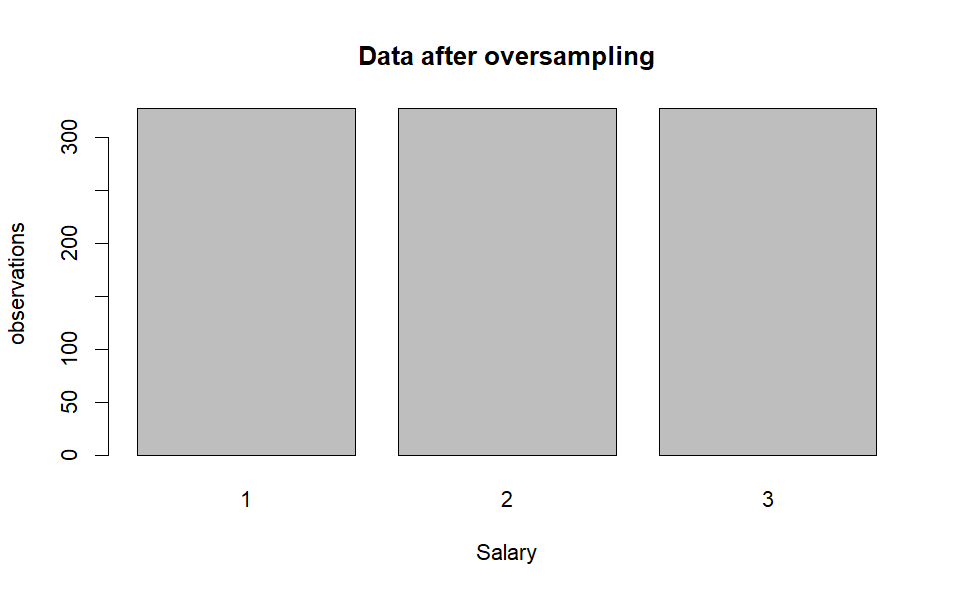

```r
plot(Employees$Salary)
title(main = "Data after oversampling", xlab = "Salary", ylab = "observations")
```

### 6.0.0 Classification

We used classification techniques to apply supervised learning to our data. We applied a decision tree for classification, which is a recursive method that generates a tree with leaf nodes pointing to the final decisions. Our model will predict the salary classification (600-1000, 1000-1600, 1600-2600). The rest of the attributes (education, job rate, job status, location, Years, Department and permission) are used to make the prediction. As for the ID, since it useless for information gain we did not use it. Also, to consume the complexity; we did not use the Start Date attribute. However, to be consistent we used the same formula for all methods except Gain ratio; since the decision tree will be complex, so we be content with Job Status, Job Rate , Department and Permissions which are the most 4 important attributes as mentioned in the feature selection.

The dataset is divided into two sets using this technique: The training set and the testing test. We need training data to train the model, so to achieve the greatest accuracy, we tried three different sizes of training subsets: 65%, 70%, and 75%, because the size of our dataset is limited. Because our model’s capacity to accurately forecast class label for new tuples is dependent on the operation of creating and training the model, we always assigned the training subset the largest percentage of our dataset.

```r
str(Employees)
```

```
'data.frame':   984 obs. of  10 variables:
 $ ID         : chr  "4Z68N9" "6K52P8" "2P43W9" "9G76H4" ...
 $ Education  : num  1 4 1 5 3 3 1 3 4 1 ...
 $ Department : num  5 4 9 4 4 13 15 15 15 15 ...
 $ Job Status : num  1 1 1 1 1 1 1 1 1 1 ...
 $ Location   : num  3 4 1 2 3 4 1 2 4 4 ...
 $ Start Date : POSIXct, format: "2018-07-24" "2016-05-11" "2012-10-20" ...
 $ Years      : num  1 3 7 6 6 5 0 8 6 0 ...
 $ Job Rate   : num  1 4 4 3 4 2 2 2 4 2 ...
 $ Permissions: num  1 6 3 4 10 8 13 13 5 1 ...
 $ Salary     : Factor w/ 3 levels "1","2","3": 1 1 1 1 1 1 1 1 1 1 ...
```

#### 6.1.0 information gain Information gain

(rpart) is a measure used in decision tree algorithms. It is used to evaluate the quality of a split in a decision tree by measuring the reduction in entropy in the dataset.

The information gain approach in rpart considers various potential splits based on different features in the dataset. For each split, the information gain is calculated by comparing the entropy of the original dataset with the weighted average of the entropies of the resulting subsets. The split that maximizes the information gain is chosen as the best split, as it leads to subsets with the highest level of homogeneity or purity.

When building a decision tree using rpart, the algorithm iterates through all possible splits and selects the one with the highest information gain. This process is repeated recursively for each resulting subset until a stopping criterion is met, such as reaching a maximum tree depth or a minimum number of samples in a leaf node.

#### 6.1.1 information gain (70% , 30%)

```r
# 1.a fixed random seed to make results reproducible
set.seed(1234)
```

```r
# 2.Split the datasets into two subsets: Training(70%) and Testing(30%):
ind <- sample(2, nrow(Employees), replace = TRUE, prob = c(0.7, 0.3))
train.data <- Employees[ind == 1, ]
test.data <- Employees[ind == 2, ]
```

```r
# 3.Converting attribute to factor
train.data$Years <- factor(train.data$Years)
test.data$Years <- factor(test.data$Years)
train.data$'Job Rate' <- factor(train.data$'Job Rate')
test.data$'Job Rate' <- factor(test.data$'Job Rate')
train.data$Permissions <- factor(train.data$Permissions)
test.data$Permissions <- factor(test.data$Permissions)
train.data$ID <- factor(train.data$ID)
test.data$ID <- factor(test.data$ID)
train.data$'Start Date' <- factor(train.data$'Start Date')
test.data$'Start Date' <- factor(test.data$'Start Date')
train.data$Education <- factor(train.data$Education)
test.data$Education <- factor(test.data$Education)
train.data$Department <- factor(train.data$Department)
test.data$Department <- factor(test.data$Department)
train.data$'Job Status' <- factor(train.data$'Job Status')
test.data$'Job Status' <- factor(test.data$'Job Status')
train.data$Location <- factor(train.data$Location)
test.data$Location <- factor(test.data$Location)
```

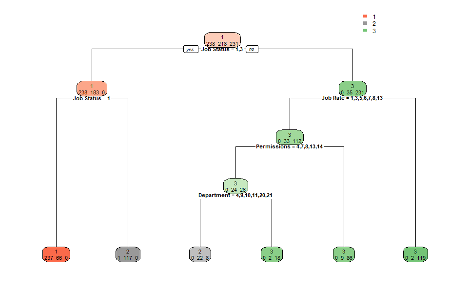

```r
# 4.Creating the tree
EmployeesTree <- rpart(Salary ~ Years + Education + Department + `Job Status` + Location + `Job Rate` + Permissions , data = train.data,parm=list(split="information"))

# 5.Visualize the decision tree using rpart.plot
rpart.plot(EmployeesTree, cex = 0.5, extra = 1)
```

```r
# 6.Make predictions on the test set
predictions <- predict(EmployeesTree, test.data, type = "class")  # Assuming it's a classification problem

# 7.Evaluate the accuracy of the predictions
accuracy <- sum(predictions == test.data$Salary) / nrow(test.data)


# 8.Confusion matrix
conf_matrix <- table(predictions, test.data$Salary)

# 9.Calculate evaluation metrics
TP <- conf_matrix[2, 2]  # True Positives
TN <- conf_matrix[1, 1]  # True Negatives
FP <- conf_matrix[2, 1]  # False Positives
FN <- conf_matrix[1, 2]  # False Negatives


# 10.Calculate precision
precision <- TP / (TP + FP)

# 11.Calculate sensitivity (True Positive Rate or Recall)
sensitivity <- TP / (TP + FN)

# 12.Calculate specificity (True Negative Rate)
specificity <- TN / (TN + FP)

# 13.Output the evaluation metrics
print(paste("Accuracy:", accuracy))
```

```
[1] "Accuracy: 0.784511784511784"
```

```r
print(paste("Precision:", precision))
```

```
[1] "Precision: 1"
```

```r
print(paste("Sensitivity (Recall):", sensitivity))
```

```
[1] "Sensitivity (Recall): 0.571428571428571"
```

```r
print(paste("Specificity:",specificity))
```

```
[1] "Specificity: 1"
```

#### 6.1.2 information gain (75% , 25%)

```r
# 1.a fixed random seed to make results reproducible
set.seed(1234)
```

```r
# 2.Split the datasets into two subsets: Training(75%) and Testing(25%):
ind <- sample(2, nrow(Employees), replace = TRUE, prob = c(0.75, 0.25))
train.data <- Employees[ind == 1, ]
test.data <- Employees[ind == 2, ]
```

```r
# 3.Converting attribute to factor
train.data$Years <- factor(train.data$Years)
test.data$Years <- factor(test.data$Years)
train.data$'Job Rate' <- factor(train.data$'Job Rate')
test.data$'Job Rate' <- factor(test.data$'Job Rate')
train.data$Permissions <- factor(train.data$Permissions)
test.data$Permissions <- factor(test.data$Permissions)
train.data$ID <- factor(train.data$ID)
test.data$ID <- factor(test.data$ID)
train.data$'Start Date' <- factor(train.data$'Start Date')
test.data$'Start Date' <- factor(test.data$'Start Date')
train.data$Education <- factor(train.data$Education)
test.data$Education <- factor(test.data$Education)
train.data$Department <- factor(train.data$Department)
test.data$Department <- factor(test.data$Department)
train.data$'Job Status' <- factor(train.data$'Job Status')
test.data$'Job Status' <- factor(test.data$'Job Status')
train.data$Location <- factor(train.data$Location)
test.data$Location <- factor(test.data$Location)
```

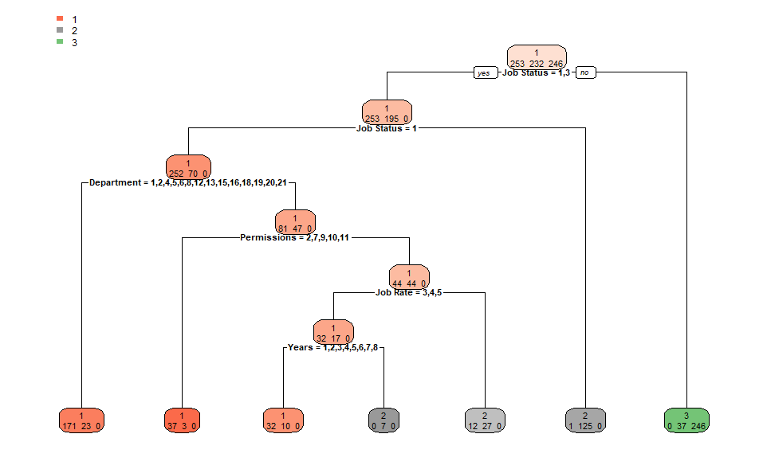

```r
# 4.Creating the tree
EmployeesTree <- rpart(Salary ~ Years + Education + Department + `Job Status` + Location + `Job Rate` + Permissions , data = train.data,parm=list(split="information"))

# 5.Visualize the decision tree using rpart.plot
rpart.plot(EmployeesTree, cex = 0.5, extra = 1)
```

```r
# 6.Make predictions on the test set
predictions <- predict(EmployeesTree, test.data, type = "class")  # Assuming it's a classification problem

# 7.Evaluate the accuracy of the predictions
accuracy <- sum(predictions == test.data$Salary) / nrow(test.data)



# 8.Confusion matrix
conf_matrix <- table(predictions, test.data$Salary)

# 9.Calculate evaluation metrics
TP <- conf_matrix[2, 2]  # True Positives
TN <- conf_matrix[1, 1]  # True Negatives
FP <- conf_matrix[2, 1]  # False Positives
FN <- conf_matrix[1, 2]  # False Negatives


# 10.Calculate precision
precision <- TP / (TP + FP)

# 11.Calculate sensitivity (True Positive Rate or Recall)
sensitivity <- TP / (TP + FN)

# 12.Calculate specificity (True Negative Rate)
specificity <- TN / (TN + FP)

# 13.Output the evaluation metrics
print(paste("Accuracy:", accuracy))
```

```
[1] "Accuracy: 0.8300395256917"
```

```r
print(paste("Precision:", precision))
```

```
[1] "Precision: 0.920634920634921"
```

```r
print(paste("Sensitivity (Recall):", sensitivity))
```

```
[1] "Sensitivity (Recall): 0.674418604651163"
```

```r
print(paste("Specificity:",specificity))
```

```
[1] "Specificity: 0.933333333333333"
```

#### 6.1.3 information gain (65% , 35%)

```r
# 1.a fixed random seed to make results reproducible
set.seed(1234)
```

```r
# 2.Split the datasets into two subsets: Training(65%) and Testing(35%):
ind <- sample(2, nrow(Employees), replace = TRUE, prob = c(0.65, 0.35))
train.data <- Employees[ind == 1, ]
test.data <- Employees[ind == 2, ]
```

```r
# 3.Converting attribute to factor
train.data$Years <- factor(train.data$Years)
test.data$Years <- factor(test.data$Years)
train.data$'Job Rate' <- factor(train.data$'Job Rate')
test.data$'Job Rate' <- factor(test.data$'Job Rate')
train.data$Permissions <- factor(train.data$Permissions)
test.data$Permissions <- factor(test.data$Permissions)
train.data$ID <- factor(train.data$ID)
test.data$ID <- factor(test.data$ID)
train.data$'Start Date' <- factor(train.data$'Start Date')
test.data$'Start Date' <- factor(test.data$'Start Date')
train.data$Education <- factor(train.data$Education)
test.data$Education <- factor(test.data$Education)
train.data$Department <- factor(train.data$Department)
test.data$Department <- factor(test.data$Department)
train.data$'Job Status' <- factor(train.data$'Job Status')
test.data$'Job Status' <- factor(test.data$'Job Status')
train.data$Location <- factor(train.data$Location)
test.data$Location <- factor(test.data$Location)
```

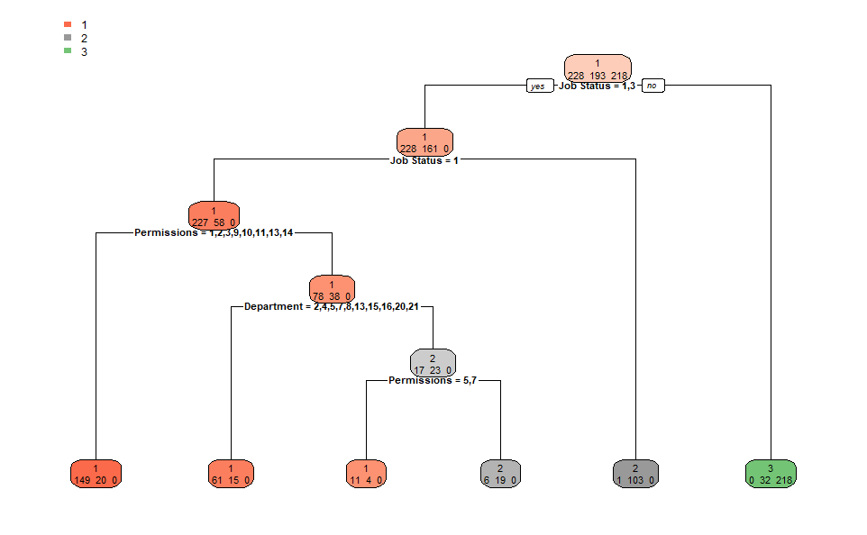

```r
# 4.Creating the tree
EmployeesTree <- rpart(Salary ~ Years + Education + Department + `Job Status` + Location + `Job Rate` + Permissions , data = train.data,parm=list(split="information"))

# 5.Visualize the decision tree using rpart.plot
rpart.plot(EmployeesTree, cex = 0.5, extra = 1)
```

```r
# 6.Make predictions on the test set
predictions <- predict(EmployeesTree, test.data, type = "class")  # Assuming it's a classification problem

# 7.Evaluate the accuracy of the predictions
accuracy <- sum(predictions == test.data$Salary) / nrow(test.data)

# 8.Confusion matrix
conf_matrix <- table(predictions, test.data$Salary)

# 9.Calculate evaluation metrics
TP <- conf_matrix[2, 2]  # True Positives
TN <- conf_matrix[1, 1]  # True Negatives
FP <- conf_matrix[2, 1]  # False Positives
FN <- conf_matrix[1, 2]  # False Negatives


# 10.Calculate precision
precision <- TP / (TP + FP)

# 11.Calculate sensitivity (True Positive Rate or Recall)
sensitivity <- TP / (TP + FN)

# 12.Calculate specificity (True Negative Rate)
specificity <- TN / (TN + FP)

# 13.Output the evaluation metrics
print(paste("Accuracy:", accuracy))
```

```
[1] "Accuracy: 0.834782608695652"
```

```r
print(paste("Precision:", precision))
```

```
[1] "Precision: 0.953488372093023"
```

```r
print(paste("Sensitivity (Recall):", sensitivity))
```

```
[1] "Sensitivity (Recall): 0.683333333333333"
```

```r
print(paste("Specificity:",specificity))
```

```
[1] "Specificity: 0.96"
```

#### 6.1.4 Comparison:

### Table 2

| Information Gain | 70% Train , 30% Test | 75% Train , 25% Test | 65% Train , 35% Test |
| --- | --- | --- | --- |
| Accuracy | 78% | 83% | 83% |
| Precision | 100% | 92% | 95% |
| Sensitivity | 57% | 67% | 68% |
| Specificity | 100% | 93% | 96% |

#### 6.1.5 Discussion:

The accuracy metric measures the overall correctness of the model’s predictions. Both the 75% Train, 25% Test and 65% Train, 35% Test partitions have higher accuracy compared to the 70% Train, 30% Test partition.

Precision measures the proportion of correctly predicted positive instances out of the total instances predicted as positive. The 70% Train, 30% Test partition has the highest precision, followed by the 65% Train, 35% Test partition, and then the 75% Train, 25% Test partition.

Sensitivity, also known as recall or true positive rate, measures the proportion of actual positive instances correctly identified by the model. The 65% Train, 35% Test partition has the highest sensitivity, followed by the 75% Train, 25% Test partition, and then the 70% Train, 30% Test partition.

#### 6.2.0 Gini Index

Gini index (rpart) can be considered as a measure for the level of impurity in a dataset. When building the tree, decision tree algorithms frequently use it to determine the split’s quality.

The approach takes into consideration several possible splits depending on distinct aspects in the dataset in order to employ the Gini index in a decision tree. Every split’s Gini index is computed, and the split with the lowest value is chosen. The selected split produces the resulting subsets with the best level of homogeneity or purity.

#### 6.2.1 Gini Index (70% , 30%)

```r
# 1.a fixed random seed to make results reproducible
set.seed(1234)
```

```r
# 2.Split the datasets into two subsets: Training(70%) and Testing(30%):
ind <- sample(2, nrow(Employees), replace = TRUE, prob = c(0.7, 0.3))
train_data <- Employees[ind == 1, ]
test_data <- Employees[ind == 2, ]
```

```r
# 3.Converting attribute to factor
train_data$Years <- factor(train_data$Years)
test_data$Years <- factor(test_data$Years)
train_data$'Job Rate' <- factor(train_data$'Job Rate')
test_data$'Job Rate' <- factor(test_data$'Job Rate')
train_data$Permissions <- factor(train_data$Permissions)
test_data$Permissions <- factor(test_data$Permissions)
train_data$ID <- factor(train_data$ID)
test_data$ID <- factor(test_data$ID)
train_data$'Start Date' <- factor(train_data$'Start Date')
test_data$'Start Date' <- factor(test_data$'Start Date')
train_data$Education <- factor(train_data$Education)
test_data$Education <- factor(test_data$Education)
train_data$Department <- factor(train_data$Department)
test_data$Department <- factor(test_data$Department)
train_data$'Job Status' <- factor(train_data$'Job Status')
test_data$'Job Status' <- factor(test_data$'Job Status')
train_data$Location <- factor(train_data$Location)
test_data$Location <- factor(test_data$Location)
```

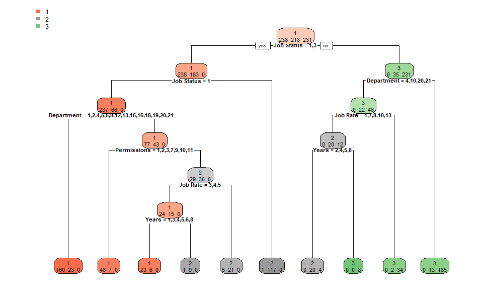

```r
# 4.Creating the tree
EmployeesTree <- rpart(Salary ~ Years + Education + Department + `Job Status` + Location + `Job Rate` + Permissions , data = train_data,parm=list(split="gini"))

# 5.Visualize the decision tree using rpart.plot
rpart.plot(EmployeesTree, cex = 0.5, extra = 1)
```

```r
# 6.Make predictions on the test set
predictions <- predict(EmployeesTree, test_data, type = "class")  # Assuming it's a classification problem

# 7.Evaluate the accuracy of the predictions
accuracy <- sum(predictions == test_data$Salary) / nrow(test_data)

# 8.Confusion matrix
conf_matrix <- table(predictions, test_data$Salary)

# 9.Calculate evaluation metrics
TP <- conf_matrix[2, 2]  # True Positives
TN <- conf_matrix[1, 1]  # True Negatives
FP <- conf_matrix[2, 1]  # False Positives
FN <- conf_matrix[1, 2]  # False Negatives


# 10.Calculate precision
precision <- TP / (TP + FP)

# 11.Calculate sensitivity (True Positive Rate or Recall)
sensitivity <- TP / (TP + FN)

# 12.Calculate specificity (True Negative Rate)
specificity <- TN / (TN + FP)

# 13.Output the evaluation metrics
print(paste("Accuracy:", accuracy))
```

```
[1] "Accuracy: 0.835016835016835"
```

```r
print(paste("Precision:", precision))
```

```
[1] "Precision: 0.922077922077922"
```

```r
print(paste("Sensitivity (Recall):", sensitivity))
```

```
[1] "Sensitivity (Recall): 0.702970297029703"
```

```r
print(paste("Specificity:",specificity))
```

```
[1] "Specificity: 0.933333333333333"
```

#### 6.2.2 Gini Index (75% , 25%)

```r
# 1.a fixed random seed to make results reproducible
set.seed(1234)
```

```r
# 2.Split the datasets into two subsets: Training(75%) and Testing(25%):
ind <- sample(2, nrow(Employees), replace = TRUE, prob = c(0.75, 0.25))
train_data <- Employees[ind == 1, ]
test_data <- Employees[ind == 2, ]
```

```r
# 3.Converting attribute to factor
train_data$Years <- factor(train_data$Years)
test_data$Years <- factor(test_data$Years)
train_data$'Job Rate' <- factor(train_data$'Job Rate')
test_data$'Job Rate' <- factor(test_data$'Job Rate')
train_data$Permissions <- factor(train_data$Permissions)
test_data$Permissions <- factor(test_data$Permissions)
train_data$ID <- factor(train_data$ID)
test_data$ID <- factor(test_data$ID)
train_data$'Start Date' <- factor(train_data$'Start Date')
test_data$'Start Date' <- factor(test_data$'Start Date')
train_data$Education <- factor(train_data$Education)
test_data$Education <- factor(test_data$Education)
train_data$Department <- factor(train_data$Department)
test_data$Department <- factor(test_data$Department)
train_data$'Job Status' <- factor(train_data$'Job Status')
test_data$'Job Status' <- factor(test_data$'Job Status')
train_data$Location <- factor(train_data$Location)
test_data$Location <- factor(test_data$Location)
```

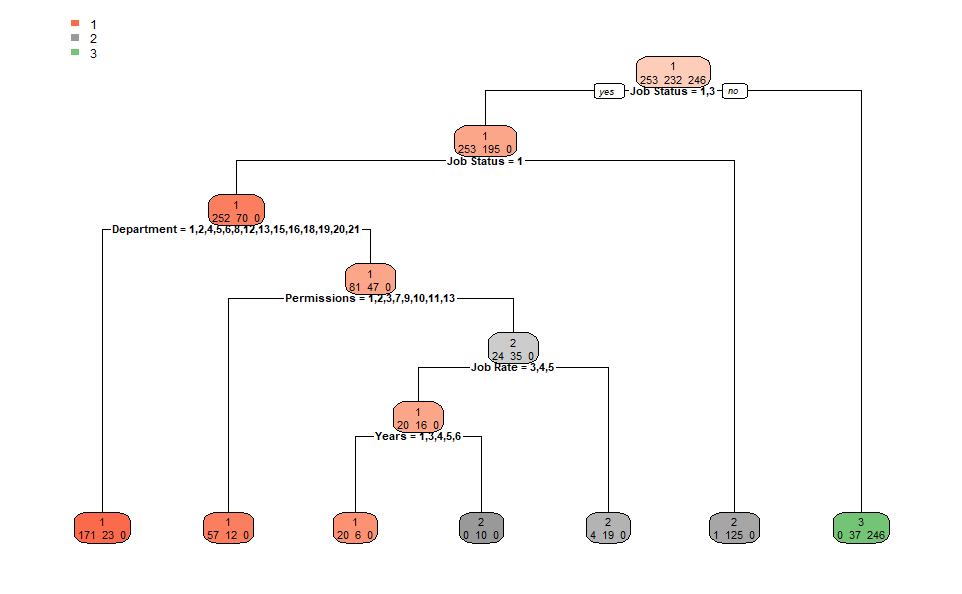

```r
# 4.Creating the tree
EmployeesTree <- rpart(Salary ~ Years + Education + Department + `Job Status` + Location + `Job Rate` + Permissions , data = train_data,parm=list(split="gini"))

# 5.Visualize the decision tree using rpart.plot
rpart.plot(EmployeesTree, cex = 0.5, extra = 1)
```

```r
# 6.Make predictions on the test set
predictions <- predict(EmployeesTree, test_data, type = "class")  # Assuming it's a classification problem

# 7.Evaluate the accuracy of the predictions
accuracy <- sum(predictions == test_data$Salary) / nrow(test_data)

# 8.Confusion matrix
conf_matrix <- table(predictions, test_data$Salary)

# 9.Calculate evaluation metrics
TP <- conf_matrix[2, 2]  # True Positives
TN <- conf_matrix[1, 1]  # True Negatives
FP <- conf_matrix[2, 1]  # False Positives
FN <- conf_matrix[1, 2]  # False Negatives


# 10.Calculate precision
precision <- TP / (TP + FP)

# 11.Calculate sensitivity (True Positive Rate or Recall)
sensitivity <- TP / (TP + FN)

# 12.Calculate specificity (True Negative Rate)
specificity <- TN / (TN + FP)

# 13.Output the evaluation metrics
print(paste("Accuracy:", accuracy))
```

```
[1] "Accuracy: 0.826086956521739"
```

```r
print(paste("Precision:", precision))
```

```
[1] "Precision: 0.933333333333333"
```

```r
print(paste("Sensitivity (Recall):", sensitivity))
```

```
[1] "Sensitivity (Recall): 0.651162790697674"
```

```r
print(paste("Specificity:",specificity))
```

```
[1] "Specificity: 0.946666666666667"
```

#### 6.2.3 Gini Index (65% , 35%)

```r
# 1.a fixed random seed to make results reproducible
set.seed(1234)
```

```r
# 2.Split the datasets into two subsets: Training(65%) and Testing(35%):
ind <- sample(2, nrow(Employees), replace = TRUE, prob = c(0.65, 0.35))
train_data <- Employees[ind == 1, ]
test_data <- Employees[ind == 2, ]
```

```r
# 3.Converting attribute to factor
train_data$Years <- factor(train_data$Years)
test_data$Years <- factor(test_data$Years)
train_data$'Job Rate' <- factor(train_data$'Job Rate')
test_data$'Job Rate' <- factor(test_data$'Job Rate')
train_data$Permissions <- factor(train_data$Permissions)
test_data$Permissions <- factor(test_data$Permissions)
train_data$ID <- factor(train_data$ID)
test_data$ID <- factor(test_data$ID)
train_data$'Start Date' <- factor(train_data$'Start Date')
test_data$'Start Date' <- factor(test_data$'Start Date')
train_data$Education <- factor(train_data$Education)
test_data$Education <- factor(test_data$Education)
train_data$Department <- factor(train_data$Department)
test_data$Department <- factor(test_data$Department)
train_data$'Job Status' <- factor(train_data$'Job Status')
test_data$'Job Status' <- factor(test_data$'Job Status')
train_data$Location <- factor(train_data$Location)
test_data$Location <- factor(test_data$Location)
```

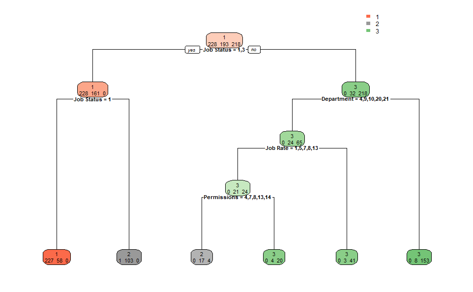

```r
# 4.Creating the tree
EmployeesTree <- rpart(Salary ~ Years + Education + Department + `Job Status` + Location + `Job Rate` + Permissions , data = train_data,parm=list(split="gini"))

# 5.Visualize the decision tree using rpart.plot
rpart.plot(EmployeesTree, cex = 0.5, extra = 1)
```

```r
# 6.Make predictions on the test set
predictions <- predict(EmployeesTree, test_data, type = "class")  # Assuming it's a classification problem

# 7.Evaluate the accuracy of the predictions
accuracy <- sum(predictions == test_data$Salary) / nrow(test_data)

# 8.Confusion matrix
conf_matrix <- table(predictions, test_data$Salary)

# 9.Calculate evaluation metrics
TP <- conf_matrix[2, 2]  # True Positives
TN <- conf_matrix[1, 1]  # True Negatives
FP <- conf_matrix[2, 1]  # False Positives
FN <- conf_matrix[1, 2]  # False Negatives


# 10.Calculate precision
precision <- TP / (TP + FP)

# 11.Calculate sensitivity (True Positive Rate or Recall)
sensitivity <- TP / (TP + FN)

# 12.Calculate specificity (True Negative Rate)
specificity <- TN / (TN + FP)

# 13.Output the evaluation metrics
print(paste("Accuracy:", accuracy))
```

```
[1] "Accuracy: 0.808695652173913"
```

```r
print(paste("Precision:", precision))
```

```
[1] "Precision: 1"
```

```r
print(paste("Sensitivity (Recall):", sensitivity))
```

```
[1] "Sensitivity (Recall): 0.59349593495935"
```

```r
print(paste("Specificity:",specificity))
```

```
[1] "Specificity: 1"
```

#### 6.2.4 Comparison:

### Table 3

| Gini Index | 70% Train , 30% Test | 75% Train , 25% Test | 65% Train , 35% Test |
| --- | --- | --- | --- |
| Accuracy | 83% | 82% | 80% |
| Precision | 92% | 93% | 100% |
| Sensitivity | 70% | 65% | 59% |
| Specificity | 93% | 94% | 100% |

#### 6.2.5 Discussion:

The accuracy metric measures the overall correctness of the model’s predictions. The 70% Train, 30% Test partition has the highest accuracy, followed by the 75% Train, 25% Test partition, and then the 65% Train, 35% Test partition.

Precision measures the proportion of correctly predicted positive instances out of the total instances predicted as positive. The 65% Train, 35% Test partition has the highest precision, followed by the 75% Train, 25% Test partition, and then the 70% Train, 30% Test partition.

Sensitivity, also known as recall or true positive rate, measures the proportion of actual positive instances correctly identified by the model. The 70% Train, 30% Test partition has the highest sensitivity, followed by the 75% Train, 25% Test partition, and then the 65% Train, 35% Test partition.

Specificity measures the proportion of actual negative instances correctly identified by the model. The 65% Train, 35% Test partition has the highest specificity, followed by the 75% Train, 25% Test partition, and then the 70% Train, 30% Test partition.

In summary, the performance of the Gini Index partition also varies depending on the train-test split percentages. The 70% Train, 30% Test partition generally outperforms the other partitions in terms of accuracy. However, the 65% Train, 35% Test partition has the highest precision, while the 70% Train, 30% Test partition has the highest sensitivity. The 65% Train, 35% Test partition also has the highest specificity.

#### 6.3.0 Gain Ratio

Gain ratio (C.50) is a measure utilized in decision tree algorithms to assess the quality of a split by considering both the information gain and the intrinsic information of a feature. It factors in the entropy or impurity of a dataset and the potential information obtained from dividing the data based on a specific feature.

The algorithm examines the gain ratios of different features while employing the gain ratio under a decision tree, selecting the feature with the highest ratio as the ideal split. This will reduce the likelihood of bias toward attributes with a high number of values or categories.

#### 6.3.1 Gain Ratio (70% , 30%)

```r
# 1.a fixed random seed to make results reproducible
set.seed(1234)
```

```r
# 2.Split the datasets into two subsets: Training(70%) and Testing(30%):
train_indices <- sample(1:nrow(Employees), nrow(Employees) * 0.7)
trainData <- Employees[train_indices, ]
testData <- Employees[-train_indices , ]
```

```r
# 3.Converting attribute to factor
trainData$Years <- factor(trainData$Years)
testData$Years <- factor(testData$Years)
trainData$'Job Rate' <- factor(trainData$'Job Rate')
testData$'Job Rate' <- factor(testData$'Job Rate')
trainData$Permissions <- factor(trainData$Permissions)
testData$Permissions <- factor(testData$Permissions)
trainData$ID <- factor(trainData$ID)
testData$ID <- factor(testData$ID)
trainData$'Start Date' <- factor(trainData$'Start Date')
testData$'Start Date' <- factor(testData$'Start Date')
trainData$Education <- factor(trainData$Education)
testData$Education <- factor(testData$Education)
trainData$Department <- factor(trainData$Department)
testData$Department <- factor(testData$Department)
trainData$'Job Status' <- factor(trainData$'Job Status')
testData$'Job Status' <- factor(testData$'Job Status')
trainData$Location <- factor(trainData$Location)
testData$Location <- factor(testData$Location)
trainData$Salary <- factor(trainData$Salary)
testData$Salary <- factor(testData$Salary)
```

```r
# 4.Creating the tree
model1 <- C5.0(Salary ~ `Job Status` + `Job Rate` + Permissions, data = trainData)

# 5.Make predictions on the test set
predictions <- predict(model1, testData, type = "class")

# 6.Evaluate the accuracy of the predictions
accuracy <- sum(predictions == testData$Salary) / nrow(testData)

# 7.Confusion matrix
conf_matrix <- table(predictions, testData$Salary)

# 8.Calculate evaluation metrics
TP <- conf_matrix[2, 2]  # True Positives
TN <- conf_matrix[1, 1]  # True Negatives
FP <- conf_matrix[2, 1]  # False Positives
FN <- conf_matrix[1, 2]  # False Negatives


# 9.Calculate precision
precision <- TP / (TP + FP)

# 10.Calculate sensitivity (True Positive Rate or Recall)
sensitivity <- TP / (TP + FN)

# 11.Calculate specificity (True Negative Rate)
specificity <- TN / (TN + FP)

# 12.Output the evaluation metrics
print(paste("Accuracy:", accuracy))
```

```
[1] "Accuracy: 0.864864864864865"
```

```r
print(paste("Precision:", precision))
```

```
[1] "Precision: 1"
```

```r
print(paste("Sensitivity (Recall):", sensitivity))
```

```
[1] "Sensitivity (Recall): 0.602564102564103"
```

```r
print(paste("Specificity:",specificity))
```

```
[1] "Specificity: 1"
```

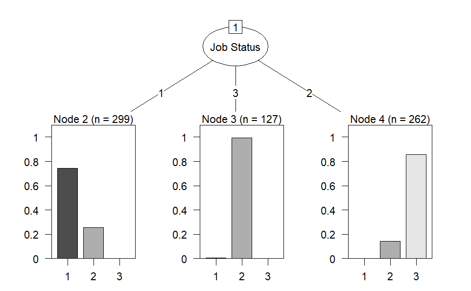

```r
# 13.Visualize the decision tree using plot
plot(model1)
```

#### 6.3.2 Gain Ratio (75% , 25%)

```r
# 1.a fixed random seed to make results reproducible
set.seed(1234)
```

```r
# 2.Split the datasets into two subsets: Training(75%) and Testing(25%):
train_indices <- sample(1:nrow(Employees), nrow(Employees) * 0.75)
trainData <- Employees[train_indices, ]
testData <- Employees[-train_indices , ]
```

```r
# 3.Converting attribute to factor
trainData$Years <- factor(trainData$Years)
testData$Years <- factor(testData$Years)
trainData$'Job Rate' <- factor(trainData$'Job Rate')
testData$'Job Rate' <- factor(testData$'Job Rate')
trainData$Permissions <- factor(trainData$Permissions)
testData$Permissions <- factor(testData$Permissions)
trainData$ID <- factor(trainData$ID)
testData$ID <- factor(testData$ID)
trainData$'Start Date' <- factor(trainData$'Start Date')
testData$'Start Date' <- factor(testData$'Start Date')
trainData$Education <- factor(trainData$Education)
testData$Education <- factor(testData$Education)
trainData$Department <- factor(trainData$Department)
testData$Department <- factor(testData$Department)
trainData$'Job Status' <- factor(trainData$'Job Status')
testData$'Job Status' <- factor(testData$'Job Status')
trainData$Location <- factor(trainData$Location)
testData$Location <- factor(testData$Location)
trainData$Salary <- factor(trainData$Salary)
testData$Salary <- factor(testData$Salary)
```

```r
# 4.Creating the tree
model2 <- C5.0(Salary ~ `Job Status` + `Job Rate` + Department + Permissions, data = trainData, control = C5.0Control(CF = 0.1))

# 5.Make predictions on the test set
predictions <- predict(model2, testData, type = "class")

# 6.Evaluate the accuracy of the predictions
accuracy <- sum(predictions == testData$Salary) / nrow(testData)


# 7.Confusion matrix
conf_matrix <- table(predictions, testData$Salary)

# 8.Calculate evaluation metrics
TP <- conf_matrix[2, 2]  # True Positives
TN <- conf_matrix[1, 1]  # True Negatives
FP <- conf_matrix[2, 1]  # False Positives
FN <- conf_matrix[1, 2]  # False Negatives


# 9.Calculate precision
precision <- TP / (TP + FP)

# 10.Calculate sensitivity (True Positive Rate or Recall)
sensitivity <- TP / (TP + FN)

# 11.Calculate specificity (True Negative Rate)
specificity <- TN / (TN + FP)

# 12.Output the evaluation metrics
print(paste("Accuracy:", accuracy))
```

```
[1] "Accuracy: 0.861788617886179"
```

```r
print(paste("Precision:", precision))
```

```
[1] "Precision: 1"
```

```r
print(paste("Sensitivity (Recall):", sensitivity))
```

```
[1] "Sensitivity (Recall): 0.609375"
```

```r
print(paste("Specificity:",specificity))
```

```
[1] "Specificity: 1"
```

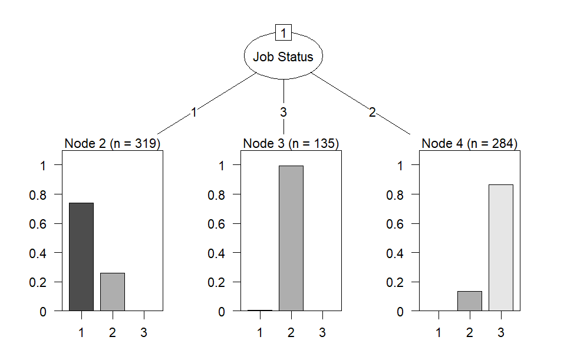

```r
# 13.Visualize the decision tree using plot
plot(model2)
```

#### 6.3.3 Gain Ratio (65% , 35%)

```r
# 1.a fixed random seed to make results reproducible
set.seed(1234)
```

```r
# 2.Split the datasets into two subsets: Training(65%) and Testing(35%):
train_indices <- sample(1:nrow(Employees), nrow(Employees) * 0.65)
trainData <- Employees[train_indices, ]
testData <- Employees[-train_indices , ]
```

```r
# 3.Converting attribute to factor
trainData$Years <- factor(trainData$Years)
testData$Years <- factor(testData$Years)
trainData$'Job Rate' <- factor(trainData$'Job Rate')
testData$'Job Rate' <- factor(testData$'Job Rate')
trainData$Permissions <- factor(trainData$Permissions)
testData$Permissions <- factor(testData$Permissions)
trainData$ID <- factor(trainData$ID)
testData$ID <- factor(testData$ID)
trainData$'Start Date' <- factor(trainData$'Start Date')
testData$'Start Date' <- factor(testData$'Start Date')
trainData$Education <- factor(trainData$Education)
testData$Education <- factor(testData$Education)
trainData$Department <- factor(trainData$Department)
testData$Department <- factor(testData$Department)
trainData$'Job Status' <- factor(trainData$'Job Status')
testData$'Job Status' <- factor(testData$'Job Status')
trainData$Location <- factor(trainData$Location)
testData$Location <- factor(testData$Location)
trainData$Salary <- factor(trainData$Salary)
testData$Salary <- factor(testData$Salary)
```

```r
# 4.Train a CART model
model3 <- C5.0(Salary ~ `Job Status` + `Job Rate` + Department + Permissions, data = trainData, control = C5.0Control(CF = 0.1))


# 5.Make predictions on the test dataset
predictions <- predict(model3, testData, type = "class")


# 6.Evaluate the accuracy of the predictions
accuracy <- sum(predictions == testData$Salary) / nrow(testData)


# 7.Confusion matrix
conf_matrix <- table(predictions, testData$Salary)

# 8.Calculate evaluation metrics
TP <- conf_matrix[2, 2]  # True Positives
TN <- conf_matrix[1, 1]  # True Negatives
FP <- conf_matrix[2, 1]  # False Positives
FN <- conf_matrix[1, 2]  # False Negatives


# 9.Calculate precision
precision <- TP / (TP + FP)

# 10.Calculate sensitivity (True Positive Rate or Recall)
sensitivity <- TP / (TP + FN)

# 11.Calculate specificity (True Negative Rate)
specificity <- TN / (TN + FP)

# 12.Output the evaluation metrics
print(paste("Accuracy:", accuracy))
```

```
[1] "Accuracy: 0.855072463768116"
```

```r
print(paste("Precision:", precision))
```

```
[1] "Precision: 1"
```

```r
print(paste("Sensitivity (Recall):", sensitivity))
```

```
[1] "Sensitivity (Recall): 0.617021276595745"
```

```r
print(paste("Specificity:",specificity))
```

```
[1] "Specificity: 1"
```

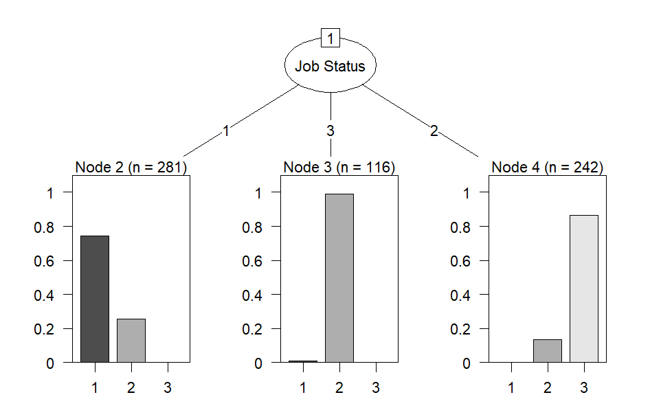

```r
# 13.Visualize the decision tree using plot
plot(model3)
```

#### 6.3.4 Comparison:

### Table 4

[output not shown]

#### 6.3.5 Discussion:

The accuracy metric measures the overall correctness of the model’s predictions. The 70% Train, 30% Test and 75% Train, 25% Test partitions have the highest accuracy, followed by the 65% Train, 35% Test partition.

Sensitivity, also known as recall or true positive rate, measures the proportion of actual positive instances correctly identified by the model. The sensitivity values are similar across all three partitions, with the 65% Train, 35% Test partition having a slightly higher sensitivity.

Specificity measures the proportion of actual negative instances correctly identified by the model. All three partitions have a perfect specificity, indicating that they correctly identify all negative instances.

### 7.0.0 Clustering

Description of Clustering: Clustering is an unsupervised learning technique in machine learning. Clustering groups similar data points together based on some characteristics.

library(factoextra)

# 7.1.0 First K-mean (k=2)

1. Deleting columns

```r
Sal <- Employees$Salary
##Delete columns
Employees <- Employees[, !names(Employees) %in% c("Salary","ID", "Start Date")]
```

Reason for removing some columns: We removed “Salary” because it is our class label and we are dealing with an unsupervised learning technique which means we don’t need the class label. We removed ” Start Date” because it had “unknown” type and it was not possible to convert its type to numric in order to start with clustering. We as well removed “ID” because it is of type “character” and converting it to numric will help us with nothing in our dataset.

2. Creating two clusters #Cluster k=2

```r
#calculate k-mean k=2
km <- kmeans(Employees, centers= 2, iter.max = 100 , algorithm="Lloyd", nstart=100)
km
```

[output not shown]

3. visualizing the result in graphical format of two clusters

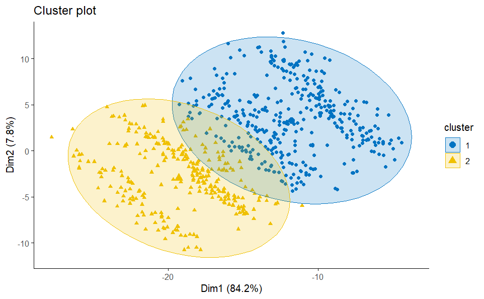

```r
#plot k-mean
fviz_cluster(list(data = Employees, cluster = km$cluster),
             ellipse.type = "norm", geom = "point", stand = FALSE,
             palette = "jco", ggtheme = theme_classic())
```

Description of plotting the k-mean: visualizing results of a k-means clustering in a graphical format.

4. calculating the Average Silhouette Coefficient of two clusters

```r
#avg silhouette
library(cluster)
silh <- silhouette(km$cluster, dist(Employees))
rownames(silh) <- rownames(Employees)
fviz_silhouette(silh)
```

|  | cluster | size | ave.sil.width |
| --- | --- | --- | --- |
| 1 | 1 | 559 | 0.28 |
| 2 | 2 | 425 | 0.31 |

|  | cluster <fctr> | size <int> | ave.sil.width <dbl> |  |
| --- | --- | --- | --- | --- |
| 1 | 1 | 559 | 0.28 |  |
| 2 | 2 | 425 | 0.31 |  |

2 rows

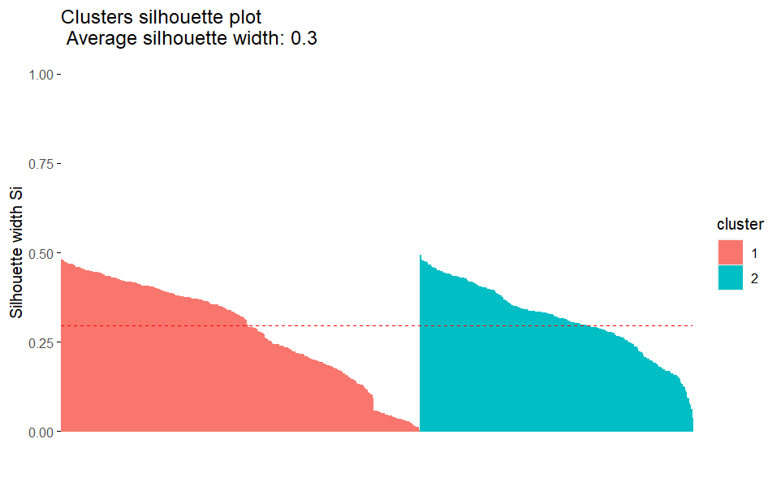

Description of average silhouette coefficient: The average silhouette coefficient over all data points is computed. The average silhouette value that is high suggests that the clustering configuration is suitable and the clusters are well separated.

5. calculating the Total Within Cluster Sum of two clusters

```r
# Total sum of squares
km$tot.withinss
```

```
[1] 44923.21
```

Description of Total sum of squares It is the sum of the squared distances between each data point in the dataset and the centroid of its assigned cluster

6. calculating BCubed precision and recall of two clusters

```r
cluster_assignments <- c(km$cluster)
ground_truth_labels <- c(Sal)
data <- data.frame(cluster = cluster_assignments, label = ground_truth_labels)
# Function to calculate BCubed precision and recall
calculate_bcubed_metrics <- function(data) {
  n <- nrow(data)
  precision_sum <- 0
  recall_sum <- 0

  for (i in 1:n) {
    cluster <- data$cluster[i]
    label <- data$label[i]

    # Count the number of items from the same category within the same cluster
    same_category_same_cluster <- sum(data$label[data$cluster == cluster] == label)

    # Count the total number of items in the same cluster
    total_same_cluster <- sum(data$cluster == cluster)

    # Count the total number of items with the same category
    total_same_category <- sum(data$label == label)

    # Calculate precision and recall for the current item and add them to the sums
    precision_sum <- precision_sum + same_category_same_cluster / total_same_cluster
    recall_sum <- recall_sum + same_category_same_cluster / total_same_category
  }

  # Calculate average precision and recall
  precision <- precision_sum / n
  recall <- recall_sum / n

  return(list(precision = precision, recall = recall))
}

# Calculate BCubed precision and recall
metrics <- calculate_bcubed_metrics(data)
# Extract precision and recall from the metrics
precision <- metrics$precision
recall <- metrics$recall
# Print the results
cat("BCubed Precision:", precision, "\n")
```

```
BCubed Precision: 0.3379242
```

```r
cat("BCubed Recall:", recall, "\n")
```

```
BCubed Recall: 0.5160309
```

### Description of BCubed precision and recall

Precision: measures the accuracy of the clustering results with respect to individual data points. It is the ratio of correctly clustered instances to the total instances in a cluster. Recall: measures the ability of the clustering algorithm to capture all instances of a particular category or class

#7.1.2 Second K-mean (k=3)

1. creating the 3 clusters

#Cluster k=3

```r
#calculate k-mean k=3
km <- kmeans(Employees, centers= 3, iter.max = 100 , algorithm="Lloyd", nstart=100)
km
```

[output not shown]

2. visualizing the result in graphical format of three clusters

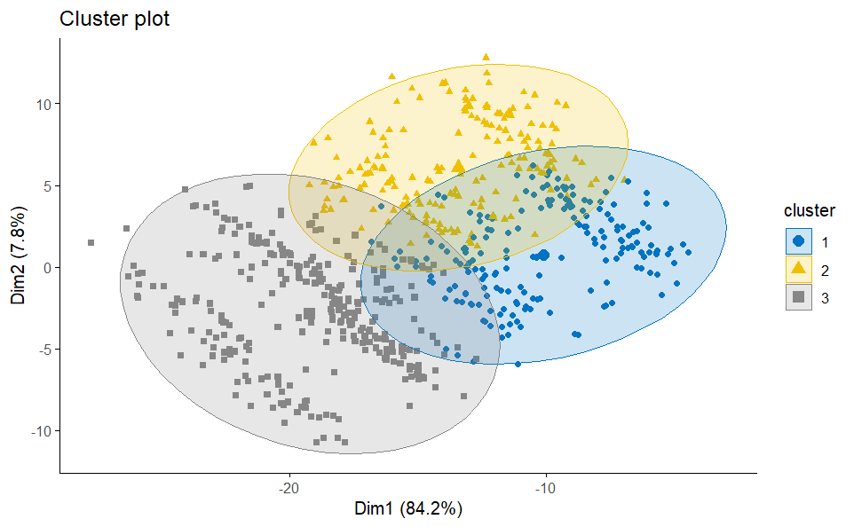

```r
#plot k-mean
fviz_cluster(list(data = Employees, cluster = km$cluster),
             ellipse.type = "norm", geom = "point", stand = FALSE,
             palette = "jco", ggtheme = theme_classic())
```

3. calculating the Average Silhouette Coefficient of three clusters

```r
#avg silhouette
library(cluster)
silh <- silhouette(km$cluster, dist(Employees))
rownames(silh) <- rownames(Employees)
fviz_silhouette(silh)
```

|  | cluster | size | ave.sil.width |
| --- | --- | --- | --- |
| 1 | 1 | 284 | 0.23 |
| 2 | 2 | 266 | 0.26 |
| 3 | 3 | 434 | 0.25 |

|  | cluster <fctr> | size <int> | ave.sil.width <dbl> |  |
| --- | --- | --- | --- | --- |
| 1 | 1 | 284 | 0.23 |  |
| 2 | 2 | 266 | 0.26 |  |
| 3 | 3 | 434 | 0.25 |  |

3 rows

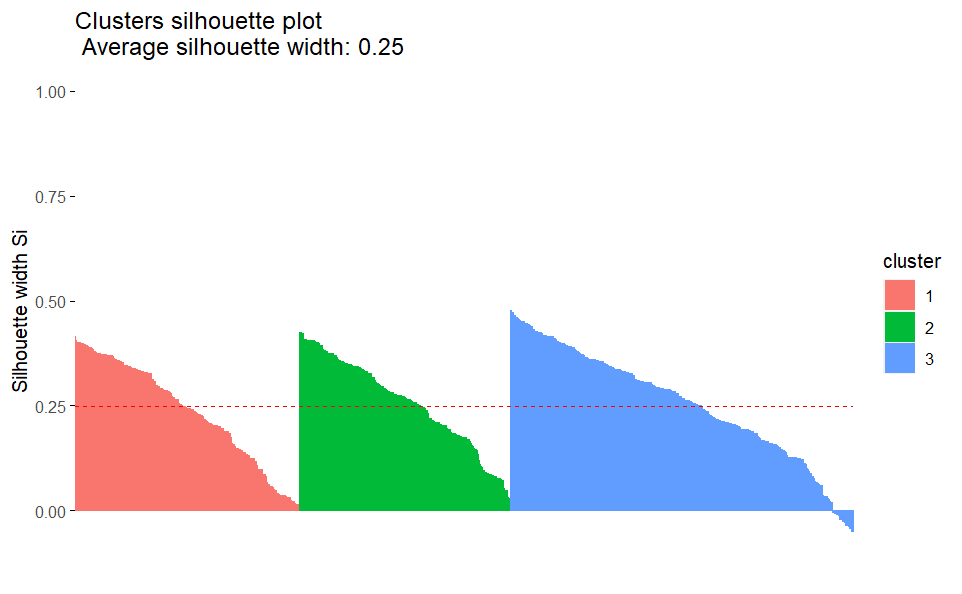

4. calculating the Total Within Cluster Sum of three clusters

```r
# Total sum of squares
km$tot.withinss
```

```
[1] 37492.04
```

5. calculating BCubed precision and recall of three clusters

```r
cluster_assignments <- c(km$cluster)
ground_truth_labels <- c(Sal)
data <- data.frame(cluster = cluster_assignments, label = ground_truth_labels)
# Function to calculate BCubed precision and recall
calculate_bcubed_metrics <- function(data) {
  n <- nrow(data)
  precision_sum <- 0
  recall_sum <- 0

  for (i in 1:n) {
    cluster <- data$cluster[i]
    label <- data$label[i]

    # Count the number of items from the same category within the same cluster
    same_category_same_cluster <- sum(data$label[data$cluster == cluster] == label)

    # Count the total number of items in the same cluster
    total_same_cluster <- sum(data$cluster == cluster)

    # Count the total number of items with the same category
    total_same_category <- sum(data$label == label)

    # Calculate precision and recall for the current item and add them to the sums
    precision_sum <- precision_sum + same_category_same_cluster / total_same_cluster
    recall_sum <- recall_sum + same_category_same_cluster / total_same_category
  }

  # Calculate average precision and recall
  precision <- precision_sum / n
  recall <- recall_sum / n

  return(list(precision = precision, recall = recall))
}

# Calculate BCubed precision and recall
metrics <- calculate_bcubed_metrics(data)
# Extract precision and recall from the metrics
precision <- metrics$precision
recall <- metrics$recall
# Print the results
cat("BCubed Precision:", precision, "\n")
```

```
BCubed Precision: 0.3364937
```

```r
cat("BCubed Recall:", recall, "\n")
```

```
BCubed Recall: 0.3543774
```

#7.1.3 Third K-mean (k=4)

1. creating the 4 clusters

#Cluster k=4

```r
#calculate k-mean k=4
km <- kmeans(Employees, centers= 4, iter.max = 100 , algorithm="Lloyd", nstart=100)
km
```

[output not shown]

2.visualizing the result in graphical format of four clusters

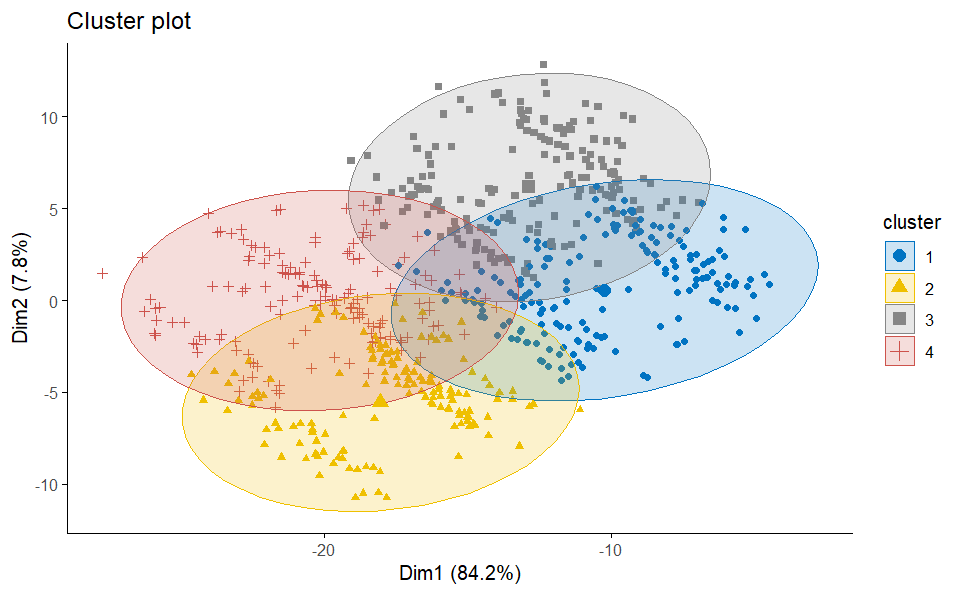

```r
#plot k-mean
fviz_cluster(list(data = Employees, cluster = km$cluster),
             ellipse.type = "norm", geom = "point", stand = FALSE,
             palette = "jco", ggtheme = theme_classic())
```

3. calculating the Average Silhouette Coefficient of four clusters

```r
#avg silhouette
library(cluster)
silh <- silhouette(km$cluster, dist(Employees))
rownames(silh) <- rownames(Employees)
fviz_silhouette(silh)
```

|  | cluster | size | ave.sil.width |
| --- | --- | --- | --- |
| 1 | 1 | 270 | 0.21 |
| 2 | 2 | 215 | 0.23 |
| 3 | 3 | 264 | 0.23 |
| 4 | 4 | 235 | 0.22 |

|  | cluster <fctr> | size <int> | ave.sil.width <dbl> |  |
| --- | --- | --- | --- | --- |
| 1 | 1 | 270 | 0.21 |  |
| 2 | 2 | 215 | 0.23 |  |
| 3 | 3 | 264 | 0.23 |  |
| 4 | 4 | 235 | 0.22 |  |

4 rows

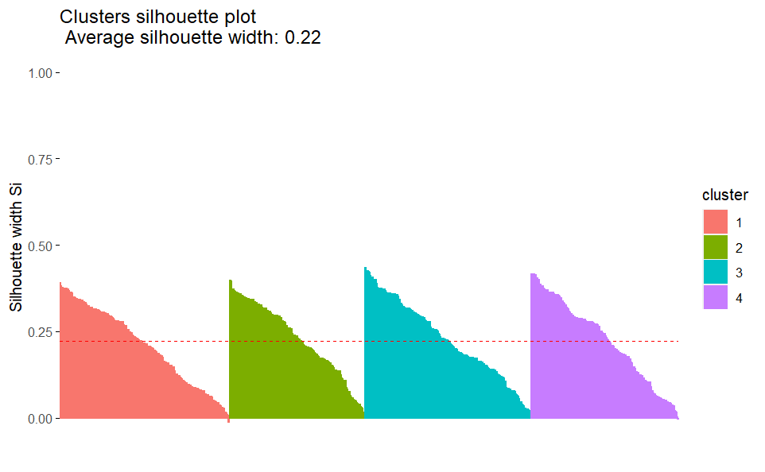

4. calculating the Total Within Cluster Sum of four clusters

```r
# Total sum of squares
km$tot.withinss
```

```
[1] 32306.99
```

5. calculating BCubed precision and recall of four clusters

```r
cluster_assignments <- c(km$cluster)
ground_truth_labels <- c(Sal)
data <- data.frame(cluster = cluster_assignments, label = ground_truth_labels)
# Function to calculate BCubed precision and recall
calculate_bcubed_metrics <- function(data) {
  n <- nrow(data)
  precision_sum <- 0
  recall_sum <- 0

  for (i in 1:n) {
    cluster <- data$cluster[i]
    label <- data$label[i]

    # Count the number of items from the same category within the same cluster
    same_category_same_cluster <- sum(data$label[data$cluster == cluster] == label)

    # Count the total number of items in the same cluster
    total_same_cluster <- sum(data$cluster == cluster)

    # Count the total number of items with the same category
    total_same_category <- sum(data$label == label)

    # Calculate precision and recall for the current item and add them to the sums
    precision_sum <- precision_sum + same_category_same_cluster / total_same_cluster
    recall_sum <- recall_sum + same_category_same_cluster / total_same_category
  }

  # Calculate average precision and recall
  precision <- precision_sum / n
  recall <- recall_sum / n

  return(list(precision = precision, recall = recall))
}

# Calculate BCubed precision and recall
metrics <- calculate_bcubed_metrics(data)
# Extract precision and recall from the metrics
precision <- metrics$precision
recall <- metrics$recall
# Print the results
cat("BCubed Precision:", precision, "\n")
```

```
BCubed Precision: 0.3360443
```

```r
cat("BCubed Recall:", recall, "\n")
```

```
BCubed Recall: 0.2540836
```

7.1.4 Using Elbow method

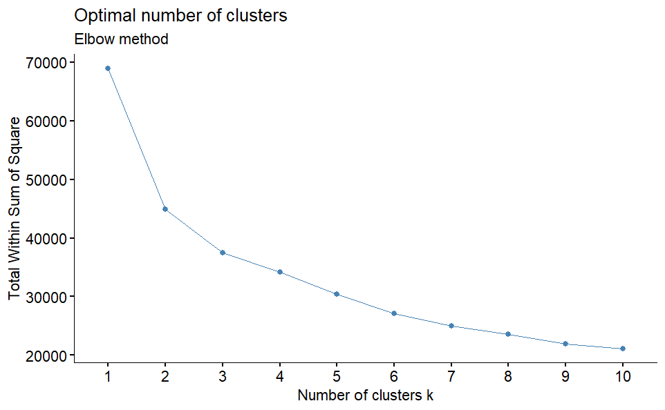

```r
#####Elbow with wss
fviz_nbclust(Employees, kmeans, method = "wss")+ labs(subtitle = "Elbow method")
```

Description of Elbow Method: The Elbow Method is one of the methods used to determine the optimal number of clusters.

### 7.1.5 Comparison:

###Table 5

[output not shown]

### 7.2.0 Discussion:

The model with the number of clusters k=2 seems to be the optimal number of clustering since most of the evaluation methods’ results supports it, we also applied the Elbow Method and we had the result of k=2.